# Tutorial 1: Discovery of cellular modules in scRNA-seq data

CoVarNet is a computational framework aiming to unravel the coordination among multiple cell types by analyzing the covariance in the frequencies of cell types across various samples.

This tutorial shows how to use CoVarNet to discover co-occurring cellular modules in annotated scRNA-seq data. We analysis a comprehensive pan-tissue cell atlas at single-cell resolution(a total of 2,293,951 cells from 706 normal samples across 35 human tissue types), and reveals recurrent multicellular ecosystems across the human body.

### Workflow diagram

CoVarNet employs two parallel modules to collaboratively determine the CM networks:

The first module applies non-negative matrix factorization (NMF) to the cell subset frequency matrix, identifying a set of meta-subsets that prioritize cell subsets based on their weights. The top cell subsets of each meta-subset act as co-occurring nodes in a single CM network.

The second module is designed to identify specifically correlated cell subset pairs, acting as potential edges.

Ultimately, multiple CM networks are constructed by interconnecting co-occurring nodes via these potential edges.

### Loading packages

```r
library(CoVarNet)
```

The R packages listed below are required for running CoVarNet. The version numbers indicate the package versions used for testing the CoVarNet code. Other R versions might work too.

R (v4.1.2).

R packages: dplyr(v1.1.4), NMF(v0.30.1), Seurat(v5.1.0), cluster(v2.1.6), sp(2.1-4), spdep(v1.3-5), igraph(v1.6.0), circlize(v0.4.15), ComplexHeatmap (v2.15.4), ggsci(v3.0.3), grid(v4.1.2), psych(v2.4.3), RColorBrewer(v1.1-3), ggplot2(v3.5.0), viridis(v0.6.5), tidytext(v0.4.1), dendextend(v1.17.1).

These packages, together with the other resources pre-stored in the CoVarNet folder, allow users to:

Perform the discovery of cellular modules in scRNA-seq data (Tutorial 1).

Perform the recovery of cellular modules in scRNA-seq data and spatial transcriptomics data (Tutorials 2).

### Preparing annotation files

```r
meta<-readRDS("data/example_discovery.rds")
meta[1:5,1:3]
```

```
##                                sampleID majorCluster     subCluster
## D01-CTCAGAAAGTGAATTG-1-bladder  Bladder  Endothelial E04_Vein_ACKR1
## D01-ACTATCTTCTAAGCCA-1-bladder  Bladder  Endothelial E04_Vein_ACKR1
## D01-ACTGATGTCCGAACGC-1-bladder  Bladder  Endothelial E04_Vein_ACKR1
## D01-TCTTTCCGTAGCGTCC-1-bladder  Bladder  Endothelial E04_Vein_ACKR1
## D01-GCGGGTTCACACCGCA-1-bladder  Bladder  Endothelial E04_Vein_ACKR1
```

Note:

Only sorting-free samples are included. We exclude samples where certain cell types are absent due to experimental cell type enrichment operations.

Filter out samples with cell numbers less than 100. Insufficient cell numbers can lead to errors in cell frequency.

```r
meta <- meta[meta$cellSort %in% c("Mix", "Total"), ]
rt_sp <- names(table(meta$sampleID))[table(meta$sampleID) >= 100]
meta <- meta[meta$sampleID %in% rt_sp, ]
```

### Cell subset frequency matrix

For each eligible sample, we compute the frequencies of cell subsets within corresponding broad cell types. To mitigate the impact of varying numbers of cell subsets in different broad cell types, we apply normalization to correct the frequency matrix.

```r
mat_fq_raw<-freq_calculate(meta)
```

```
## `mutate_if()` ignored the following grouping variables:
## • Column `majorCluster`
```

```r
mat_fq_norm<-freq_normalize(mat_fq_raw,normalize="minmax")
dim(mat_fq_norm)
```

```
## [1]  76 510
```

normalize:[“minmax”:Min-max normalization. “zscore”:Z-Score Normalization] (Default:“minmax”)

### Performing NMF decomposition on frequency matrix

NMF identifies a set of meta-subsets that prioritize cell subsets based on their weights. To determine the optimal factorization rank(parameter K) for NMF analysis, we use the cophenetic correlation coefficient as the evaluation index. We denote the cophenetic correlation coefficient at rank k as ρk and established a procedure tailored to this context for automated determination of the optimal rank based on the following criterias:

ρk-2 < ρk-1 < ρk

ρk > ρk+1

```r
res <- nmf(mat_fq_norm, rank = 2:20, method = "nsNMF", seed = rep(123456, 6), .options = "vp")
```

```
## Compute NMF rank= 2  ... + measures ... OK
## Compute NMF rank= 3  ... + measures ... OK
## Compute NMF rank= 4  ... + measures ... OK
## Compute NMF rank= 5  ... + measures ... OK
## Compute NMF rank= 6  ... + measures ... OK
## Compute NMF rank= 7  ... + measures ... OK
## Compute NMF rank= 8  ... + measures ... OK
## Compute NMF rank= 9  ... + measures ... OK
## Compute NMF rank= 10  ... + measures ... OK
## Compute NMF rank= 11  ... + measures ... OK
## Compute NMF rank= 12  ... + measures ... OK
## Compute NMF rank= 13  ... + measures ... OK
## Compute NMF rank= 14  ... + measures ... OK
## Compute NMF rank= 15  ... + measures ... OK
## Compute NMF rank= 16  ... + measures ... OK
## Compute NMF rank= 17  ... + measures ... OK
## Compute NMF rank= 18  ... + measures ... OK
## Compute NMF rank= 19  ... + measures ... OK
## Compute NMF rank= 20  ... + measures ... OK
```

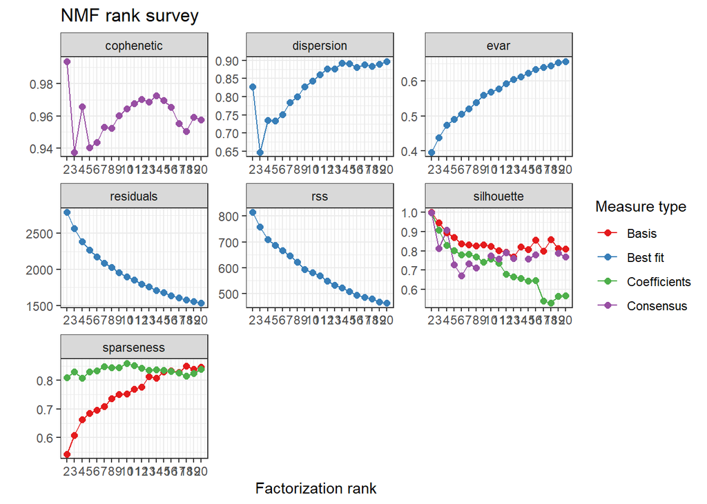

```r
plot(res)
```

Here we set rank K=12.  
Other parameters(in accordance with NMF R package(v0.30.1)):

method: Specification of the NMF algorithm.

seed: Specification of the starting point or seeding method.

nrun: Number of runs to perform.

.options: Set runtime options.

```r
K=12
NMF_K12<-nmf(mat_fq_norm, K, method = "nsNMF", seed = rep(77, 6), nrun = 30)
```

Note:To ensure consistency with the naming used in the article, we rename the cellular modules here.

```r
colnames(basis(NMF_K12))=c("CM01","CM03","CM02","CM08","CM11","CM06","CM07","CM04","CM12","CM10","CM05","CM09")
rownames(coef(NMF_K12))=c("CM01","CM03","CM02","CM08","CM11","CM06","CM07","CM04","CM12","CM10","CM05","CM09")
```

### Visualizing characteristics of CMs

NMF decomposes the frequency matrix into:

Feature matrix (cell subset*CM): A set of CMs that prioritize cell subsets based on their weights.

Coefficient matrix (CM*sample): CMs activity in each sample.

#### Visualizing the potential composition of CMs

The heatmap displays the weights of all cell subsets within each cellular module, which is obtained from the feature matrix based on NMF decomposition.

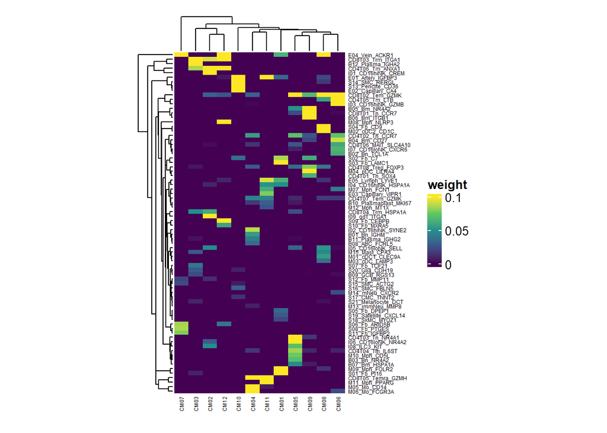

```r
gr.weight_all(NMF_K12)
```

Display the top cell subsets sorted by weights for within cellular module. These top subsets serve as potential compositions of cellular modules.

num: the number of top cell subsets

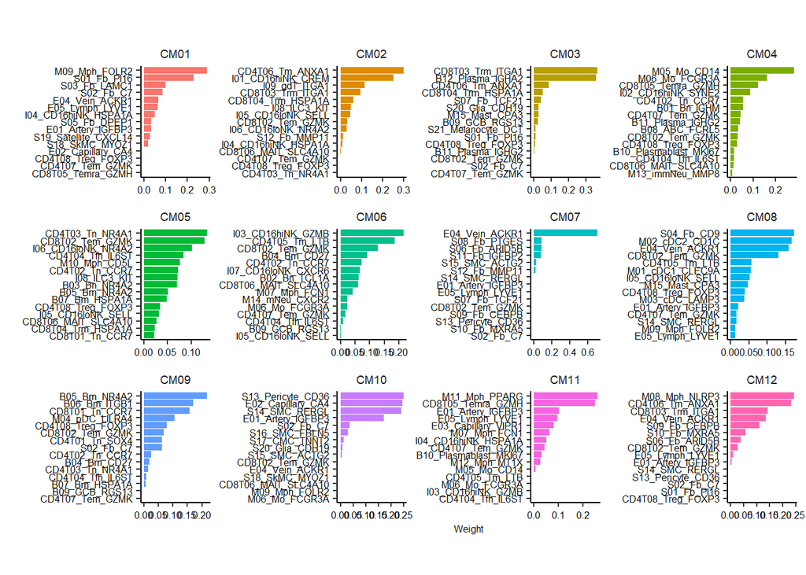

```r
gr.weight_top(NMF_K12,num=15)
```

#### Visualizing the distribution of CMs across samples

The coefficient matrix is interpreted as CMs activity in samples. All samples are categorized into mutually exclusive CM types based on their dominant CMs.

```r
h<-coef(NMF_K12)
max_cm <- apply(h, 2, function(x) rownames(h)[which.max(x)])
max_cm<-gsub("CM", "CMT",max_cm)
max_cm[1:10]
```

```
##      04     1.1     1.2     1.3     1.4     1.5     1.6     1.7     1.8     145
## "CMT07" "CMT07" "CMT12" "CMT07" "CMT08" "CMT07" "CMT08" "CMT10" "CMT07" "CMT07"
```

The heatmap displays CMs activity profiles across tissues. Each sample is assigned a dominant CM, and all samples are ordered by their CM identities and tissue types.

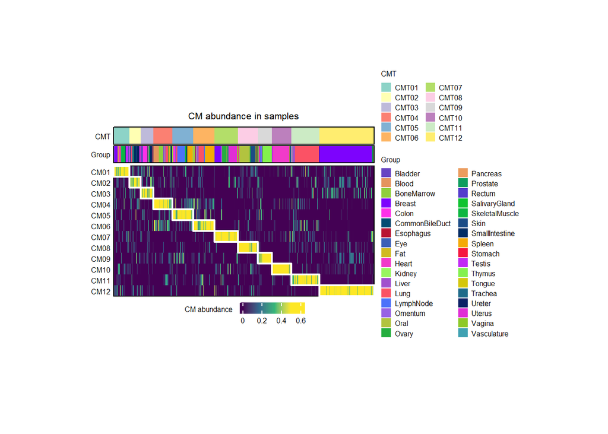

```r
gr.distribution(NMF_K12,meta=meta,group="tissue")
```

meta: The groupings of each sample(not required). If provided, it should contain at least two columns:“sampleID” and the groupings.

group: The column name that contains group information.

### Specifically correlated subset pairs

CoVarNet utilizes correlation coefficients to assess whether any two cell subsets specifically co-occur. Here we perform pairwise correlation tests based on the frequency matrix mat_fq_raw, resulting in an correlation coefficient matrix denoted as cor_pair. Then we calculate the significance “pval_fdr” and the specificity “spe” of subset pairs. For each element 𝑟,where i<j in cor_pair, its background (complementary) set is defined as {rik,rkj|k!=i,j}. The specificity is defined as the fraction of elements in the background set that not exceeding rij.  
We calculate the correlation between all pairs of cell subsets here and will filter specifically correlated pairs in the next section.

```r
cor_pair<-pair_correlation(mat_fq_raw,method="pearson")
# saveRDS(cor_pair,"./result/cor_pair.rds")
head(cor_pair)
```

```
##   subCluster1   subCluster2 correlation         pval    pval_fdr       spe
## 1 B01_Bn_IGHM  B02_Bn_TCL1A  0.24377005 6.588698e-05 0.001073016 0.9194631
## 2 B01_Bn_IGHM  B03_Bn_NR4A2  0.17929225 1.180171e-01 1.000000000 0.9127517
## 3 B01_Bn_IGHM   B04_Bm_CD27  0.08031129 1.000000e+00 1.000000000 0.7315436
## 4 B01_Bn_IGHM  B05_Bm_NR4A2 -0.02248968 1.000000e+00 1.000000000 0.4899329
## 5 B01_Bn_IGHM  B06_Bm_ITGB1  0.07052276 1.000000e+00 1.000000000 0.7046980
## 6 B01_Bn_IGHM B07_Bm_HSPA1A  0.03640481 1.000000e+00 1.000000000 0.6778523
##   majorCluster1 majorCluster2
## 1             B             B
## 2             B             B
## 3             B             B
## 4             B             B
## 5             B             B
## 6             B             B
```

### Interconnecting co-occurring nodes via specifically correlated edges to construct CM networks

In each CM network, the top subsets were considered as potential nodes and specifically correlated subset pairs are connected as edges, with isolated nodes removed. The details are as follows:

Firstly, we need to determine the upper limit of the number of cell subsets in each CM (top_n). As shown in the function gr.weight_top, we filter the top_n cell subsets with the highest weights in each CM as nodes.

Secondly, we filter specifically correlated subset pairs as edges based on the following criteria:

- coefficients > parameter corr (Default:0.2)
- pval_fdr < parameter fdr (Dafault 0.05)
- spe > 1-((top_n-1)* 2-1)/((n_all-1)* 2-1). n_all is the number of all cell subsets.

Ultimately, we utilize the igraph R package to construct a network for each CM.

```r
top_n=10
network<-cm_network(NMF_K12,cor_pair,top_n,corr=0.2,fdr=0.05)
```

The igraph R package is used to create visual representations of the CM networks. For improved clarity, nodes were color-coded according to their broad cell types, and edge color gradient was scaled proportionally to their specificities. The “each” graph shows the coordination of each CM network, while “global” graph includes all cell subsets.

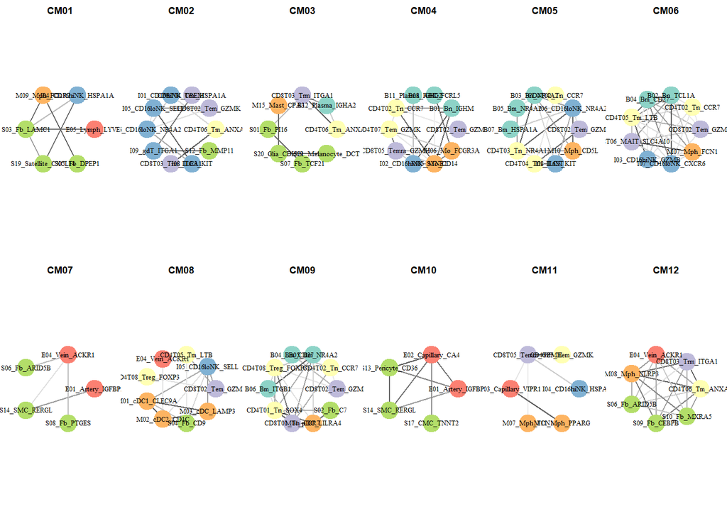

```r
each<-network$each
gr.igraph_each(each,Layout=layout_in_circle)
```

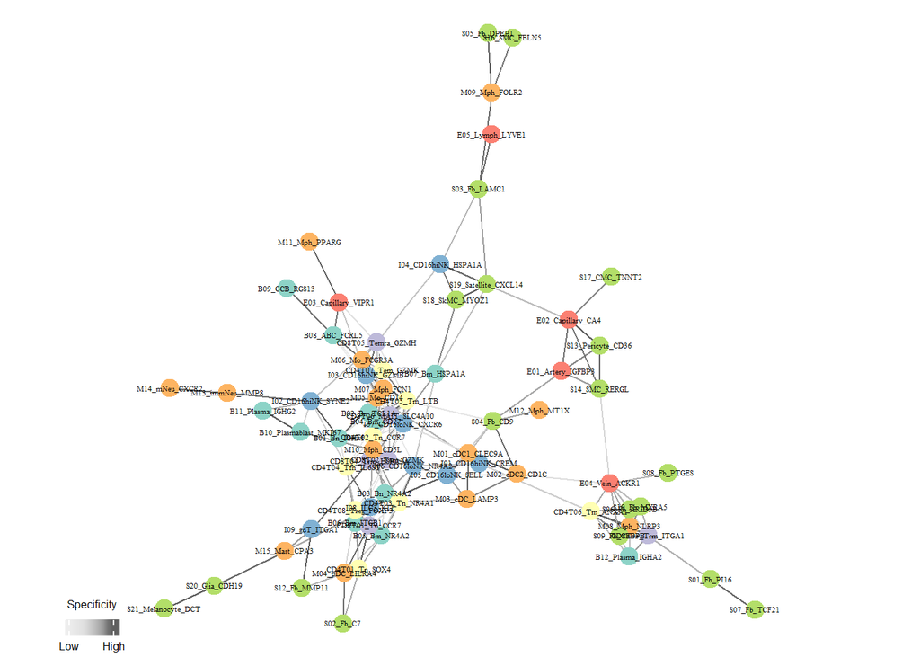

```r
global<-network$global
par(plt=c(0,1,0,1),fig = c(0,1,0,1))
gr.igraph_global(global,Layout=layout_with_fr)
```

### Exporting the components of each CM

```r
head(network$filter)
```

```
##     cm           subCluster majorCluster     weight
## 1 CM01        M09_Mph_FOLR2      Myeloid 0.29058247
## 2 CM01         S03_Fb_LAMC1      Stromal 0.09904598
## 3 CM01      E05_Lymph_LYVE1  Endothelial 0.06517205
## 4 CM01  I04_CD16hiNK_HSPA1A          ILC 0.04953647
## 5 CM01         S05_Fb_DPEP1      Stromal 0.03324351
## 6 CM01 S19_Satellite_CXCL14      Stromal 0.02850289
```

```r
saveRDS(network,"./network.rds")
```

Note: The network.rds can also serve as a reference for recovering cellular modules in Tutorial 2.